# Importing Some Important libraries

```python
import pandas as pd
import numpy
import numpy as np
import seaborn as sns
import matplotlib
import matplotlib.pyplot as plt

import os
import pylab
from Bio import Seq
from Bio import SeqIO
from Bio import AlignIO
from Bio import Align
from Bio.Align import AlignInfo
from io import StringIO
from Bio import Phylo
from Bio.Align.Applications import ClustalwCommandline
from Bio.Align import PairwiseAligner
from Bio.Align import substitution_matrices
```

# Reading The CSV File

```python
Prion_Protein_match_dataframe = pd.read_csv("D:\\Senior 1 - semester 2\\CSE486 Bioinformatics\\Project_dataset\\Prion_Protein_match_csv.csv",index_col = 0 )
Prion_Protein_match_dataframe.head()
```

| Description | Scientific Name | Max Score | Total Score | Query Cover | E value | Per. ident | Acc. Len | Accession |
| --- | --- | --- | --- | --- | --- | --- | --- | --- |
| RecName: Full=Major prion protein; Short=PrP; AltName: Full=ASCR; AltName: Full=PrP27-30; AltName: Full=PrP33-35C; AltName: CD_antigen=CD230; Flags: Precursor [Homo sapiens] | Homo sapiens | 304 | 304 | 93% | 9.000000e-104 | 99.15 | 253 | =HYPERLINK("https://www.ncbi.nlm.nih.gov/prote... |
| RecName: Full=Major prion protein; Short=PrP; AltName: Full=PrP27-30; AltName: Full=PrP33-35C; AltName: CD_antigen=CD230; Flags: Precursor [Gorilla gorilla gorilla] | Gorilla gorilla gorilla | 303 | 303 | 93% | 3.000000e-103 | 98.73 | 253 | =HYPERLINK("https://www.ncbi.nlm.nih.gov/prote... |
| RecName: Full=Major prion protein; Short=PrP; AltName: Full=PrP27-30; AltName: Full=PrP33-35C; AltName: CD_antigen=CD230; Flags: Precursor [Hylobates lar] | Hylobates lar | 301 | 301 | 93% | 1.000000e-102 | 98.31 | 253 | =HYPERLINK("https://www.ncbi.nlm.nih.gov/prote... |
| RecName: Full=Major prion protein; Short=PrP; AltName: Full=PrP27-30; AltName: Full=PrP33-35C; AltName: CD_antigen=CD230; Flags: Precursor [Pongo pygmaeus] | Pongo pygmaeus | 295 | 295 | 93% | 2.000000e-100 | 97.03 | 253 | =HYPERLINK("https://www.ncbi.nlm.nih.gov/prote... |
| RecName: Full=Major prion protein; Short=PrP; AltName: Full=PrP27-30; AltName: Full=PrP33-35C; AltName: CD_antigen=CD230; Flags: Precursor [Colobus guereza] | Colobus guereza | 294 | 294 | 93% | 9.000000e-100 | 96.19 | 253 | =HYPERLINK("https://www.ncbi.nlm.nih.gov/prote... |

# Exploratory Data Analysis (EDA)

```python
print(Prion_Protein_match_dataframe.info())
```

```
<class 'pandas.core.frame.DataFrame'>
Index: 50 entries, RecName: Full=Major prion protein; Short=PrP; AltName: Full=ASCR; AltName: Full=PrP27-30; AltName: Full=PrP33-35C; AltName: CD_antigen=CD230; Flags: Precursor [Homo sapiens] to RecName: Full=Major prion protein; Short=PrP; AltName: CD_antigen=CD230; Flags: Precursor [Tragelaphus i…
Data columns (total 8 columns):
 #   Column           Non-Null Count  Dtype
---  ------           --------------  -----
 0   Scientific Name  50 non-null     object
 1   Max Score        50 non-null     int64
 2   Total Score      50 non-null     int64
 3   Query Cover      50 non-null     object
 4   E value          50 non-null     float64
 5   Per. ident       50 non-null     float64
 6   Acc. Len         50 non-null     int64
 7   Accession        50 non-null     object
dtypes: float64(2), int64(3), object(3)
memory usage: 3.5+ KB
None
```

```python
Prion_Protein_match_dataframe.columns
```

```
Index(['Scientific Name', 'Max Score', 'Total Score', 'Query Cover', 'E value',
       'Per. ident', 'Acc. Len', 'Accession  '],
      dtype='object')
```

```python
Prion_Protein_match_dataframe.shape
```

```
(50, 8)
```

```python
print(Prion_Protein_match_dataframe['Acc. Len'].unique())
```

```
[253 245 252 260 246 241 232 238 239 256 254 255 257 264]
```

```python
print(Prion_Protein_match_dataframe['Acc. Len'].value_counts())
```

```
256    9
253    7
264    7
254    6
252    4
257    4
246    3
241    2
238    2
255    2
245    1
260    1
232    1
239    1
Name: Acc. Len, dtype: int64
```

# Visual EDA

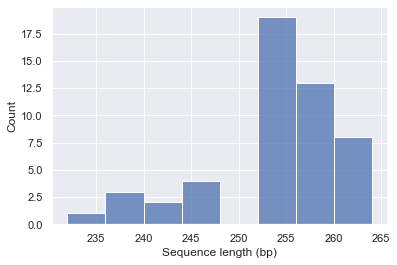

```python
sns.set_theme()
sns.histplot(Prion_Protein_match_dataframe, x="Acc. Len",bins=8)
plt.xlabel("Sequence length (bp)")
plt.ylabel("Count")
plt.show()
```

# Reading The FASTA File

```python
lines = []

with open("D:\\Senior 1 - semester 2\\CSE486 Bioinformatics\\Project_dataset\\Prion_Protein_match_fasta.fasta") as in_handle:
    record_iterator = SeqIO.parse(in_handle, "fasta")
    for _ in range(50):
        rec = next(record_iterator)
        lines.append(rec)
```

```python
print(lines)
```

```
[SeqRecord(seq=Seq('MANLGCWMLVLFVATWSDLGLCKKRPKPGGWNTGGSRYPGQGSPGGNRYPPQGG...IVG'), id='P04156.1', name='P04156.1', description='P04156.1 RecName: Full=Major prion protein; Short=PrP; AltName: Full=ASCR; AltName: Full=PrP27-30; AltName: Full=PrP33-35C; AltName: CD_antigen=CD230; Flags: Precursor [Ho…
```

# Visualizing The Protein Sequences Dot Plots

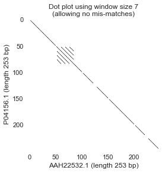

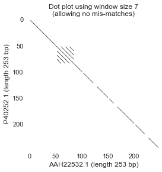

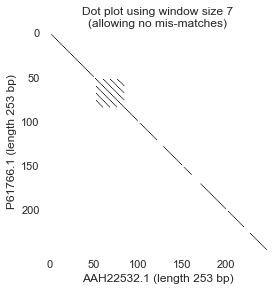

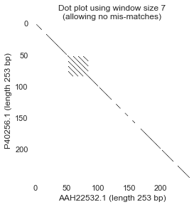

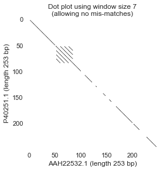

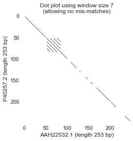

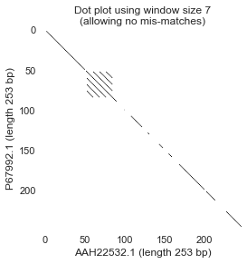

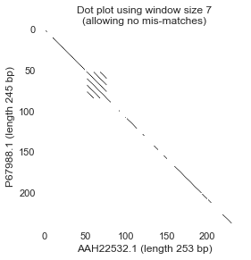

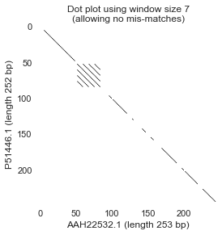

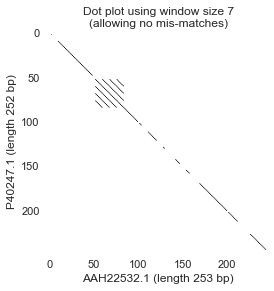

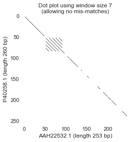

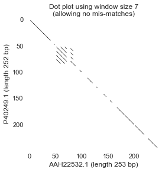

[38 more figures not shown]

```python
# Prion protein [Homo sapiens] sequence on x-axis aganist the other 50 sequences on the y-axis
window = 7

for seq_record in SeqIO.parse("D:\\Senior 1 - semester 2\\CSE486 Bioinformatics\\Project_dataset\\Prion protein [Homo sapiens].fasta", "fasta"):
    seq_one = seq_record.seq.upper()


for line in lines:
    seq_two = line.seq.upper()
    data = [
    [
        (seq_one[i : i + window] != seq_two[j : j + window])
        for j in range(len(seq_one) - window)
    ]
    for i in range(len(seq_two) - window)
    ]
    pylab.gray()
    pylab.imshow(data)
    pylab.xlabel("%s (length %i bp)" % (seq_record.id, len(seq_record)))
    pylab.ylabel("%s (length %i bp)" % (line.id, len(line)))
    pylab.title("Dot plot using window size %i\n(allowing no mis-matches)" % window)
    pylab.show()
```

# Parsing And Reading Sequence Alignments

```python
input_file = "D:\\Senior 1 - semester 2\\CSE486 Bioinformatics\\Project_dataset\\Prion_Protein_match_fasta.fasta"
records = SeqIO.parse(input_file, 'fasta')
records = list(records)

# make a copy, otherwise our generator is exhausted after calculating maxlen
maxlen = max(len(record.seq) for record in records)

# pad sequences so that they all have the same length
for record in records:
    if len(record.seq) != maxlen:
        sequence = str(record.seq).ljust(maxlen, '.')
        record.seq = Seq.Seq(sequence)
assert all(len(record.seq) == maxlen for record in records)

# write to temporary file and do alignment
output_file = '{}_padded.fasta'.format(os.path.splitext(input_file)[0])
with open(output_file, 'w') as f:
    SeqIO.write(records, f, 'fasta')
alignment = AlignIO.read(output_file, "fasta")
print(alignment)
```

```
Alignment with 50 rows and 264 columns
MANLGCWMLVLFVATWSDLGLCKKRPKPGGWNTGGSRYPGQGSP...... P04156.1
MANLGCWMLVLFVATWSDLGLCKKRPKPGGWNTGGSRYPGQGSP...... P40252.1
MANLGCWMLVLFVATWSDLGLCKKRPKPGGWNTGGSRYPGQGSP...... P61766.1
MANLGCWMLVLFVATWSNLGLCKKRPKPGGWNTGGSRYPGQGSP...... P40256.1
MANLGCWMLVLFVATWSDLGLCKKRPKPGGWNTGGSRYPGQGSP...... P40251.1
MANLGCWMLVLFVATWSDLGLCKKRPKPGGWNTGGSRYPGQGSP...... P40257.2
MANLGCWMLVLFVATWSDLGLCKKRPKPGGWNTGGSRYPGQGSP...... P67992.1
MANLGCWMLVVFVATWSDLGLCKKRPKPGGWNTGGSRYPGQGSP...... P67988.1
MANLGYWMLVLFVATWSDLGLCKKRPKPGGWNTGGSRYPGQGSP...... P51446.1
MANLGCWMLFLFVATWSDLGLCKKRPKPGGWNTGGSRYPGQGSP...... P40247.1
MANLGCWMLVLFVATWSDLGLCKKRPKPGGWNTGGSRYPGQGSP...... P40258.1
MANLGCWMLVLFVATWSDLGLCKKRPKPGGWNTGGSRYPGQGSP...... P40249.1
MLVLFVATWSDLGLCKKRPKPGGWNTGGSRYPGQGSPGGNRYPP...... P61761.1
MLVLFVATWSDLGLCKKRPKPGGWNTGGSRYPGQGSPGGNRYPP...... P40248.1
MLVVFVATWSDLGLCKKRPKPGGWNTGGSRYPGQGSPGGNRYPP...... Q95174.1
MLVLFVATWSDLGLCKKRPKPGGWNTGGSRYPGQGSPGGNRYPP...... P40246.1
MLVLFVATWSDLGLCKKRPKPGGWNTGGSRYPGQGSPGGNRYPP...... P40255.1
MLVLFVATWSDLGLCKKRPKPGGWNTGGSRYPGQGSPGGNRYPP...... Q95176.1
...
MVKSHIGSWILVLFVAMWSDVGLCKKRPKPGGGWNTGGSRYPGQ...IVG Q5UJG3.1
```

# Dealing With Alignments

## Calculating The Consensus Sequence

```python
summary_align = AlignInfo.SummaryInfo(alignment)
consensus = summary_align.dumb_consensus(threshold = 0.6)
print("The Consensus Sequence is: {}".format(consensus))
print()
print("Length of the Consensus Sequence is {}".format(len(consensus)))
```

```
The Consensus Sequence is: MXXXXXXXWXLXXXXXXXXXXXXXXXXPXXXXGXXXXGXXXXXXGXXGXXXXXXXGGGXX…

Length of the Consensus Sequence is 264
```

## Position Specific Score Matrices

Position specific score matrices (PSSMs) summarize the alignment information in a different way than a consensus, and may be useful for different tasks. **Basically, a PSSM is a count matrix.** For each column in the alignment, the number of each alphabet letters is counted and totaled. The totals are displayed relative to some representative sequence along the left axis. This sequence may be the consesus sequence, but can also be any sequence in the alignment. For instance for the alignment,

GTATC\ AT--C\ CTGTC\ the PSSM is:

```
  G A T C
G 1 1 0 1
T 0 0 3 0
A 1 1 0 0
T 0 0 2 0
C 0 0 0 3
```

#### PSSM with the consensus sequence along the side

```python
my_pssm = summary_align.pos_specific_score_matrix(consensus)
print(my_pssm)
```

```
    .   A   C   D   E   F   G   H   I   K   L   M   N   P   Q   R   S   T   V   W   Y
M  0.0 0.0 0.0 0.0 0.0 0.0 0.0 0.0 0.0 0.0 0.0 50.0 0.0 0.0 0.0 0.0 0.0 0.0 0.0 0.0 0.0
X  0.0 19.0 0.0 0.0 0.0 0.0 0.0 0.0 0.0 0.0 9.0 0.0 0.0 0.0 0.0 0.0 0.0 0.0 22.0 0.0 0.0
X  0.0 0.0 0.0 0.0 0.0 0.0 0.0 1.0 0.0 22.0 0.0 0.0 18.0 0.0 0.0 0.0 0.0 0.0 9.0 0.0 0.0
X  0.0 0.0 0.0 0.0 0.0 0.0 0.0 0.0 0.0 0.0 27.0 0.0 0.0 0.0 0.0 1.0 21.0 0.0 1.0 0.0 0.0
X  0.0 0.0 0.0 0.0 0.0 9.0 16.0 22.0 0.0 0.0 0.0 0.0 0.0 0.0 0.0 0.0 3.0 0.0 0.0 0.0 0.0
X  0.0 0.0 11.0 0.0 0.0 0.0 0.0 0.0 21.0 0.0 0.0 1.0 0.0 0.0 0.0 0.0 0.0 0.0 9.0 0.0 8.0
X  0.0 9.0 0.0 0.0 0.0 0.0 22.0 0.0 0.0 0.0 0.0 0.0 0.0 0.0 0.0 0.0 0.0 0.0 0.0 19.0 0.0
X  0.0 0.0 0.0 0.0 0.0 0.0 2.0 0.0 0.0 0.0 6.0 13.0 0.0 0.0 0.0 0.0 20.0 9.0 0.0 0.0 0.0
W  0.0 0.0 0.0 0.0 0.0 0.0 0.0 0.0 0.0 0.0 19.0 0.0 0.0 0.0 0.0 0.0 0.0 0.0 0.0 31.0 0.0
X  0.0 6.0 0.0 0.0 0.0 1.0 0.0 0.0 20.0 0.0 3.0 0.0 0.0 0.0 0.0 0.0 9.0 0.0 11.0 0.0 0.0
L  0.0 0.0 0.0 9.0 0.0 0.0 0.0 0.0 0.0 0.0 40.0 0.0 0.0 0.0 0.0 0.0 0.0 0.0 1.0 0.0 0.0
X  0.0 0.0 0.0 0.0 0.0 19.0 0.0 0.0 0.0 0.0 10.0 0.0 0.0 0.0 0.0 0.0 0.0 0.0 21.0 0.0 0.0
X  0.0 0.0 0.0 0.0 0.0 0.0 9.0 0.0 0.0 0.0 22.0 0.0 0.0 0.0 0.0 0.0 0.0 0.0 19.0 0.0 0.0
X  0.0 17.0 0.0 0.0 0.0 22.0 0.0 0.0 0.0 0.0 9.0 0.0 0.0 0.0 0.0 0.0 0.0 2.0 0.0 0.0 0.0
X  0.0 0.0 9.0 0.0 0.0 0.0 0.0 0.0 0.0 0.0 0.0 2.0 0.0 0.0 0.0 0.0 0.0 17.0 22.0 0.0 0.0
X  0.0 20.0 1.0 0.0 0.0 0.0 0.0 0.0 0.0 9.0 0.0 0.0 0.0 0.0 0.0 0.0 0.0 0.0 2.0 18.0 0.0
X  0.0 1.0 0.0 0.0 0.0 0.0 0.0 0.0 0.0 9.0 0.0 17.0 0.0 0.0 0.0 0.0 13.0 10.0 0.0 0.0 0.0
X  0.0 0.0 0.0 18.0 0.0 0.0 0.0 0.0 0.0 0.0 0.0 0.0 1.0 0.0 0.0 9.0 0.0 0.0 0.0 22.0 0.0
X  0.0 0.0 0.0 0.0 0.0 0.0 0.0 0.0 0.0 0.0 12.0 0.0 0.0 9.0 0.0 0.0 22.0 0.0 7.0 0.0 0.0
X  0.0 0.0 0.0 22.0 0.0 0.0 19.0 0.0 0.0 9.0 0.0 0.0 0.0 0.0 0.0 0.0 0.0 0.0 0.0 0.0 0.0
X  0.0 0.0 0.0 0.0 0.0 0.0 0.0 0.0 3.0 0.0 19.0 0.0 0.0 9.0 0.0 0.0 0.0 0.0 19.0 0.0 0.0
X  0.0 2.0 19.0 0.0 0.0 0.0 29.0 0.0 0.0 0.0 0.0 0.0 0.0 0.0 0.0 0.0 0.0 0.0 0.0 0.0 0.0
X  0.0 0.0 0.0 0.0 0.0 2.0 9.0 0.0 0.0 19.0 20.0 0.0 0.0 0.0 0.0 0.0 0.0 0.0 0.0 0.0 0.0
X  0.0 0.0 22.0 0.0 0.0 0.0 0.0 0.0 0.0 19.0 0.0 0.0 0.0 0.0 0.0 0.0 0.0 0.0 0.0 9.0 0.0
X  0.0 0.0 0.0 0.0 0.0 0.0 0.0 0.0 0.0 22.0 0.0 0.0 9.0 0.0 0.0 19.0 0.0 0.0 0.0 0.0 0.0
X  0.0 0.0 0.0 0.0 0.0 0.0 0.0 0.0 0.0 22.0 0.0 0.0 0.0 19.0 0.0 0.0 0.0 9.0 0.0 0.0 0.0
X  0.0 0.0 0.0 0.0 0.0 0.0 9.0 0.0 0.0 19.0 0.0 0.0 0.0 0.0 0.0 22.0 0.0 0.0 0.0 0.0 0.0
P  0.0 0.0 0.0 0.0 0.0 0.0 9.0 0.0 0.0 0.0 0.0 0.0 0.0 41.0 0.0 0.0 0.0 0.0 0.0 0.0 0.0
X  0.0 0.0 0.0 0.0 0.0 0.0 19.0 0.0 0.0 22.0 0.0 0.0 0.0 0.0 0.0 0.0 9.0 0.0 0.0 0.0 0.0
X  0.0 0.0 0.0 0.0 0.0 0.0 19.0 0.0 0.0 0.0 0.0 0.0 0.0 22.0 0.0 9.0 0.0 0.0 0.0 0.0 0.0
X  0.0 0.0 0.0 0.0 0.0 0.0 23.0 0.0 0.0 0.0 0.0 0.0 0.0 0.0 0.0 0.0 0.0 0.0 0.0 18.0 9.0
X  0.0 0.0 0.0 0.0 0.0 0.0 22.0 0.0 0.0 0.0 0.0 0.0 18.0 9.0 0.0 0.0 0.0 0.0 0.0 1.0 0.0
G  0.0 0.0 0.0 0.0 0.0 0.0 30.0 0.0 0.0 0.0 0.0 0.0 1.0 0.0 0.0 0.0 0.0 18.0 0.0 1.0 0.0
X  0.0 0.0 0.0 0.0 0.0 0.0 18.0 0.0 0.0 0.0 0.0 0.0 1.0 0.0 9.0 0.0 0.0 1.0 0.0 21.0 0.0
X  0.0 0.0 0.0 0.0 0.0 0.0 27.0 0.0 0.0 0.0 0.0 0.0 21.0 0.0 0.0 0.0 1.0 1.0 0.0 0.0 0.0
X  0.0 0.0 0.0 0.0 0.0 0.0 2.0 0.0 0.0 0.0 0.0 0.0 0.0 0.0 0.0 0.0 27.0 21.0 0.0 0.0 0.0
X  0.0 0.0 0.0 0.0 0.0 0.0 22.0 0.0 0.0 0.0 0.0 0.0 0.0 9.0 0.0 18.0 1.0 0.0 0.0 0.0 0.0
G  0.0 0.0 0.0 0.0 0.0 0.0 31.0 0.0 0.0 0.0 0.0 0.0 0.0 0.0 0.0 1.0 0.0 0.0 0.0 0.0 18.0
X  0.0 0.0 0.0 0.0 0.0 0.0 9.0 0.0 0.0 0.0 0.0 0.0 0.0 18.0 0.0 0.0 22.0 0.0 0.0 0.0 1.0
```

[output cut: 210 more lines]

```
X  10.0 0.0 0.0 0.0 0.0 7.0 0.0 0.0 6.0 0.0 20.0 0.0 0.0 7.0 0.0 0.0 0.0 0.0 0.0 0.0 0.0
X  10.0 0.0 0.0 0.0 0.0 2.0 0.0 0.0 17.0 0.0 10.0 0.0 0.0 0.0 0.0 0.0 0.0 0.0 11.0 0.0 0.0
X  10.0 0.0 0.0 0.0 0.0 9.0 4.0 0.0 14.0 0.0 3.0 1.0 0.0 0.0 0.0 0.0 1.0 0.0 8.0 0.0 0.0
X  14.0 0.0 0.0 0.0 0.0 2.0 7.0 0.0 2.0 0.0 19.0 0.0 0.0 0.0 0.0 0.0 0.0 0.0 6.0 0.0 0.0
X  21.0 0.0 0.0 0.0 0.0 0.0 6.0 0.0 9.0 0.0 12.0 0.0 0.0 0.0 0.0 0.0 0.0 0.0 2.0 0.0 0.0
X  27.0 0.0 0.0 0.0 0.0 0.0 2.0 0.0 12.0 0.0 0.0 0.0 0.0 0.0 0.0 0.0 0.0 0.0 9.0 0.0 0.0
X  29.0 0.0 0.0 0.0 0.0 1.0 9.0 0.0 0.0 0.0 0.0 0.0 0.0 0.0 0.0 0.0 7.0 0.0 4.0 0.0 0.0
X  38.0 0.0 0.0 0.0 0.0 6.0 4.0 0.0 0.0 0.0 2.0 0.0 0.0 0.0 0.0 0.0 0.0 0.0 0.0 0.0 0.0
L  42.0 0.0 0.0 0.0 0.0 0.0 0.0 0.0 1.0 0.0 7.0 0.0 0.0 0.0 0.0 0.0 0.0 0.0 0.0 0.0 0.0
I  42.0 0.0 0.0 0.0 0.0 0.0 0.0 0.0 7.0 0.0 0.0 0.0 0.0 0.0 0.0 0.0 0.0 0.0 1.0 0.0 0.0
F  42.0 0.0 0.0 0.0 0.0 7.0 1.0 0.0 0.0 0.0 0.0 0.0 0.0 0.0 0.0 0.0 0.0 0.0 0.0 0.0 0.0
L  43.0 0.0 0.0 0.0 0.0 0.0 0.0 0.0 0.0 0.0 7.0 0.0 0.0 0.0 0.0 0.0 0.0 0.0 0.0 0.0 0.0
I  43.0 0.0 0.0 0.0 0.0 0.0 0.0 0.0 7.0 0.0 0.0 0.0 0.0 0.0 0.0 0.0 0.0 0.0 0.0 0.0 0.0
V  43.0 0.0 0.0 0.0 0.0 0.0 0.0 0.0 0.0 0.0 0.0 0.0 0.0 0.0 0.0 0.0 0.0 0.0 7.0 0.0 0.0
G  43.0 0.0 0.0 0.0 0.0 0.0 7.0 0.0 0.0 0.0 0.0 0.0 0.0 0.0 0.0 0.0 0.0 0.0 0.0 0.0 0.0
```

```python
print(my_pssm[0]["M"])
```

```
50.0
```

#### PSSM with the Prion protein [Homo sapiens] sequence along the side

```python
for seq_record in SeqIO.parse("D:\\Senior 1 - semester 2\\CSE486 Bioinformatics\\Project_dataset\\Prion protein [Homo sapiens].fasta", "fasta"):
    sequence = str(seq_record.seq).ljust(264, '.')
    seq_record.seq = Seq.Seq(sequence)

second_seq = seq_record.seq
my_pssm = summary_align.pos_specific_score_matrix(second_seq)
print(my_pssm)
```

```
    .   A   C   D   E   F   G   H   I   K   L   M   N   P   Q   R   S   T   V   W   Y
M  0.0 0.0 0.0 0.0 0.0 0.0 0.0 0.0 0.0 0.0 0.0 50.0 0.0 0.0 0.0 0.0 0.0 0.0 0.0 0.0 0.0
A  0.0 19.0 0.0 0.0 0.0 0.0 0.0 0.0 0.0 0.0 9.0 0.0 0.0 0.0 0.0 0.0 0.0 0.0 22.0 0.0 0.0
N  0.0 0.0 0.0 0.0 0.0 0.0 0.0 1.0 0.0 22.0 0.0 0.0 18.0 0.0 0.0 0.0 0.0 0.0 9.0 0.0 0.0
L  0.0 0.0 0.0 0.0 0.0 0.0 0.0 0.0 0.0 0.0 27.0 0.0 0.0 0.0 0.0 1.0 21.0 0.0 1.0 0.0 0.0
G  0.0 0.0 0.0 0.0 0.0 9.0 16.0 22.0 0.0 0.0 0.0 0.0 0.0 0.0 0.0 0.0 3.0 0.0 0.0 0.0 0.0
C  0.0 0.0 11.0 0.0 0.0 0.0 0.0 0.0 21.0 0.0 0.0 1.0 0.0 0.0 0.0 0.0 0.0 0.0 9.0 0.0 8.0
W  0.0 9.0 0.0 0.0 0.0 0.0 22.0 0.0 0.0 0.0 0.0 0.0 0.0 0.0 0.0 0.0 0.0 0.0 0.0 19.0 0.0
M  0.0 0.0 0.0 0.0 0.0 0.0 2.0 0.0 0.0 0.0 6.0 13.0 0.0 0.0 0.0 0.0 20.0 9.0 0.0 0.0 0.0
L  0.0 0.0 0.0 0.0 0.0 0.0 0.0 0.0 0.0 0.0 19.0 0.0 0.0 0.0 0.0 0.0 0.0 0.0 0.0 31.0 0.0
V  0.0 6.0 0.0 0.0 0.0 1.0 0.0 0.0 20.0 0.0 3.0 0.0 0.0 0.0 0.0 0.0 9.0 0.0 11.0 0.0 0.0
L  0.0 0.0 0.0 9.0 0.0 0.0 0.0 0.0 0.0 0.0 40.0 0.0 0.0 0.0 0.0 0.0 0.0 0.0 1.0 0.0 0.0
F  0.0 0.0 0.0 0.0 0.0 19.0 0.0 0.0 0.0 0.0 10.0 0.0 0.0 0.0 0.0 0.0 0.0 0.0 21.0 0.0 0.0
V  0.0 0.0 0.0 0.0 0.0 0.0 9.0 0.0 0.0 0.0 22.0 0.0 0.0 0.0 0.0 0.0 0.0 0.0 19.0 0.0 0.0
A  0.0 17.0 0.0 0.0 0.0 22.0 0.0 0.0 0.0 0.0 9.0 0.0 0.0 0.0 0.0 0.0 0.0 2.0 0.0 0.0 0.0
T  0.0 0.0 9.0 0.0 0.0 0.0 0.0 0.0 0.0 0.0 0.0 2.0 0.0 0.0 0.0 0.0 0.0 17.0 22.0 0.0 0.0
W  0.0 20.0 1.0 0.0 0.0 0.0 0.0 0.0 0.0 9.0 0.0 0.0 0.0 0.0 0.0 0.0 0.0 0.0 2.0 18.0 0.0
S  0.0 1.0 0.0 0.0 0.0 0.0 0.0 0.0 0.0 9.0 0.0 17.0 0.0 0.0 0.0 0.0 13.0 10.0 0.0 0.0 0.0
D  0.0 0.0 0.0 18.0 0.0 0.0 0.0 0.0 0.0 0.0 0.0 0.0 1.0 0.0 0.0 9.0 0.0 0.0 0.0 22.0 0.0
L  0.0 0.0 0.0 0.0 0.0 0.0 0.0 0.0 0.0 0.0 12.0 0.0 0.0 9.0 0.0 0.0 22.0 0.0 7.0 0.0 0.0
G  0.0 0.0 0.0 22.0 0.0 0.0 19.0 0.0 0.0 9.0 0.0 0.0 0.0 0.0 0.0 0.0 0.0 0.0 0.0 0.0 0.0
L  0.0 0.0 0.0 0.0 0.0 0.0 0.0 0.0 3.0 0.0 19.0 0.0 0.0 9.0 0.0 0.0 0.0 0.0 19.0 0.0 0.0
C  0.0 2.0 19.0 0.0 0.0 0.0 29.0 0.0 0.0 0.0 0.0 0.0 0.0 0.0 0.0 0.0 0.0 0.0 0.0 0.0 0.0
K  0.0 0.0 0.0 0.0 0.0 2.0 9.0 0.0 0.0 19.0 20.0 0.0 0.0 0.0 0.0 0.0 0.0 0.0 0.0 0.0 0.0
K  0.0 0.0 22.0 0.0 0.0 0.0 0.0 0.0 0.0 19.0 0.0 0.0 0.0 0.0 0.0 0.0 0.0 0.0 0.0 9.0 0.0
R  0.0 0.0 0.0 0.0 0.0 0.0 0.0 0.0 0.0 22.0 0.0 0.0 9.0 0.0 0.0 19.0 0.0 0.0 0.0 0.0 0.0
P  0.0 0.0 0.0 0.0 0.0 0.0 0.0 0.0 0.0 22.0 0.0 0.0 0.0 19.0 0.0 0.0 0.0 9.0 0.0 0.0 0.0
K  0.0 0.0 0.0 0.0 0.0 0.0 9.0 0.0 0.0 19.0 0.0 0.0 0.0 0.0 0.0 22.0 0.0 0.0 0.0 0.0 0.0
P  0.0 0.0 0.0 0.0 0.0 0.0 9.0 0.0 0.0 0.0 0.0 0.0 0.0 41.0 0.0 0.0 0.0 0.0 0.0 0.0 0.0
G  0.0 0.0 0.0 0.0 0.0 0.0 19.0 0.0 0.0 22.0 0.0 0.0 0.0 0.0 0.0 0.0 9.0 0.0 0.0 0.0 0.0
G  0.0 0.0 0.0 0.0 0.0 0.0 19.0 0.0 0.0 0.0 0.0 0.0 0.0 22.0 0.0 9.0 0.0 0.0 0.0 0.0 0.0
W  0.0 0.0 0.0 0.0 0.0 0.0 23.0 0.0 0.0 0.0 0.0 0.0 0.0 0.0 0.0 0.0 0.0 0.0 0.0 18.0 9.0
N  0.0 0.0 0.0 0.0 0.0 0.0 22.0 0.0 0.0 0.0 0.0 0.0 18.0 9.0 0.0 0.0 0.0 0.0 0.0 1.0 0.0
T  0.0 0.0 0.0 0.0 0.0 0.0 30.0 0.0 0.0 0.0 0.0 0.0 1.0 0.0 0.0 0.0 0.0 18.0 0.0 1.0 0.0
G  0.0 0.0 0.0 0.0 0.0 0.0 18.0 0.0 0.0 0.0 0.0 0.0 1.0 0.0 9.0 0.0 0.0 1.0 0.0 21.0 0.0
G  0.0 0.0 0.0 0.0 0.0 0.0 27.0 0.0 0.0 0.0 0.0 0.0 21.0 0.0 0.0 0.0 1.0 1.0 0.0 0.0 0.0
S  0.0 0.0 0.0 0.0 0.0 0.0 2.0 0.0 0.0 0.0 0.0 0.0 0.0 0.0 0.0 0.0 27.0 21.0 0.0 0.0 0.0
R  0.0 0.0 0.0 0.0 0.0 0.0 22.0 0.0 0.0 0.0 0.0 0.0 0.0 9.0 0.0 18.0 1.0 0.0 0.0 0.0 0.0
Y  0.0 0.0 0.0 0.0 0.0 0.0 31.0 0.0 0.0 0.0 0.0 0.0 0.0 0.0 0.0 1.0 0.0 0.0 0.0 0.0 18.0
P  0.0 0.0 0.0 0.0 0.0 0.0 9.0 0.0 0.0 0.0 0.0 0.0 0.0 18.0 0.0 0.0 22.0 0.0 0.0 0.0 1.0
```

[output cut: 210 more lines]

```
L  10.0 0.0 0.0 0.0 0.0 7.0 0.0 0.0 6.0 0.0 20.0 0.0 0.0 7.0 0.0 0.0 0.0 0.0 0.0 0.0 0.0
I  10.0 0.0 0.0 0.0 0.0 2.0 0.0 0.0 17.0 0.0 10.0 0.0 0.0 0.0 0.0 0.0 0.0 0.0 11.0 0.0 0.0
V  10.0 0.0 0.0 0.0 0.0 9.0 4.0 0.0 14.0 0.0 3.0 1.0 0.0 0.0 0.0 0.0 1.0 0.0 8.0 0.0 0.0
G  14.0 0.0 0.0 0.0 0.0 2.0 7.0 0.0 2.0 0.0 19.0 0.0 0.0 0.0 0.0 0.0 0.0 0.0 6.0 0.0 0.0
.  21.0 0.0 0.0 0.0 0.0 0.0 6.0 0.0 9.0 0.0 12.0 0.0 0.0 0.0 0.0 0.0 0.0 0.0 2.0 0.0 0.0
.  27.0 0.0 0.0 0.0 0.0 0.0 2.0 0.0 12.0 0.0 0.0 0.0 0.0 0.0 0.0 0.0 0.0 0.0 9.0 0.0 0.0
.  29.0 0.0 0.0 0.0 0.0 1.0 9.0 0.0 0.0 0.0 0.0 0.0 0.0 0.0 0.0 0.0 7.0 0.0 4.0 0.0 0.0
.  38.0 0.0 0.0 0.0 0.0 6.0 4.0 0.0 0.0 0.0 2.0 0.0 0.0 0.0 0.0 0.0 0.0 0.0 0.0 0.0 0.0
.  42.0 0.0 0.0 0.0 0.0 0.0 0.0 0.0 1.0 0.0 7.0 0.0 0.0 0.0 0.0 0.0 0.0 0.0 0.0 0.0 0.0
.  42.0 0.0 0.0 0.0 0.0 0.0 0.0 0.0 7.0 0.0 0.0 0.0 0.0 0.0 0.0 0.0 0.0 0.0 1.0 0.0 0.0
.  42.0 0.0 0.0 0.0 0.0 7.0 1.0 0.0 0.0 0.0 0.0 0.0 0.0 0.0 0.0 0.0 0.0 0.0 0.0 0.0 0.0
.  43.0 0.0 0.0 0.0 0.0 0.0 0.0 0.0 0.0 0.0 7.0 0.0 0.0 0.0 0.0 0.0 0.0 0.0 0.0 0.0 0.0
.  43.0 0.0 0.0 0.0 0.0 0.0 0.0 0.0 7.0 0.0 0.0 0.0 0.0 0.0 0.0 0.0 0.0 0.0 0.0 0.0 0.0
.  43.0 0.0 0.0 0.0 0.0 0.0 0.0 0.0 0.0 0.0 0.0 0.0 0.0 0.0 0.0 0.0 0.0 0.0 7.0 0.0 0.0
.  43.0 0.0 0.0 0.0 0.0 0.0 7.0 0.0 0.0 0.0 0.0 0.0 0.0 0.0 0.0 0.0 0.0 0.0 0.0 0.0 0.0
```

## Calculating a substitution matrix from a multiple sequence alignment

Substitution matrices are an extremely important part of everyday bioinformatics work. They provide the scoring terms for classifying how likely two different residues are to substitute for each other. This is essential in doing sequence comparisons. Some famous substitution matrices are the PAM and BLOSUM series of matrices.

Biopython provides a ton of common substitution matrices, and also provides functionality for creating your own substitution matrices.

#### We Can Use Either Of the Two Parts Of Code Depending On How Big We Want Our Alignment To Be:-

-------------------------------------------Alignment between 9 sequences--------------------------------------------------

```python
# print(Prion_Protein_match_dataframe['Acc. Len'].value_counts())
```

```python
# input_file = "D:\\Senior 1 - semester 2\\CSE486 Bioinformatics\\Project_dataset\\Prion_Protein_match_fasta.fasta"
# records = SeqIO.parse(input_file, 'fasta')
# records = list(records)
# seq_256Len = []

# # make a copy, otherwise our generator is exhausted after calculating maxlen
# maxlen = max(len(record.seq) for record in records)

# for record in records:
#     if len(record.seq) == 256:
#         seq_256Len.append(record)

# print(len(seq_256Len))
```

```python
# # write to temporary file and do alignment
# output_file = '{}_padded.fasta'.format(os.path.splitext(input_file)[0])
# with open(output_file, 'w') as f:
#     SeqIO.write(seq_256Len, f, 'fasta')
# alignment_seq_256Len = AlignIO.read(output_file, "fasta")
# print(alignment_seq_256Len)
```

*############################################################################################################################*

-------------------------------------------Alignment between 50 sequences--------------------------------------------------

#### ClustalW

ClustalW is a popular command line tool for multiple sequence alignment (there is also a graphical interface called ClustalX). Biopython’s Bio.Align.Applications module has a wrapper for this alignment tool (and several others).

```python
input_file = "D:\\Senior 1 - semester 2\\CSE486 Bioinformatics\\Project_dataset\\Prion_Protein_match_fasta.fasta"
cline = ClustalwCommandline("clustalw2", infile=input_file)
print(cline)
```

```
clustalw2 -infile="D:\Senior 1 - semester 2\CSE486 Bioinformatics\Project_dataset\Prion_Protein_match_fasta.fasta"
```

```python
clustalw_exe = r"D:\\Senior 1 - semester 2\\CSE486 Bioinformatics\\ClustalX2\\clustalx.exe"
clustalw_cline = ClustalwCommandline(clustalw_exe, infile=input_file)
assert os.path.isfile(clustalw_exe), "Clustal W executable missing"
stdout, stderr = clustalw_cline()
```

```python
input_file = "D:\\Senior 1 - semester 2\\CSE486 Bioinformatics\\Project_dataset\\Prion_Protein_match_fasta.aln"
align = AlignIO.read(input_file, "clustal")
print(align)
```

```
Alignment with 50 rows and 264 columns
MANLGCWMLVLFVATWSDLGLCKKRPKPGGWNTGGSRYPGQGSP...--- P04156.1
MANLGCWMLVLFVATWSDLGLCKKRPKPGGWNTGGSRYPGQGSP...--- P40252.1
MANLGCWMLVLFVATWSDLGLCKKRPKPGGWNTGGSRYPGQGSP...--- P61766.1
MANLGCWMLVLFVATWSNLGLCKKRPKPGGWNTGGSRYPGQGSP...--- P40256.1
MANLGCWMLVLFVATWSDLGLCKKRPKPGGWNTGGSRYPGQGSP...--- P40251.1
MANLGCWMLVLFVATWSDLGLCKKRPKPGGWNTGGSRYPGQGSP...--- P40257.2
MANLGCWMLVLFVATWSDLGLCKKRPKPGGWNTGGSRYPGQGSP...--- P67992.1
MANLGCWMLVVFVATWSDLGLCKKRPKPGGWNTGGSRYPGQGSP...--- P67988.1
MANLGYWMLVLFVATWSDLGLCKKRPKPGGWNTGGSRYPGQGSP...--- P51446.1
MANLGCWMLFLFVATWSDLGLCKKRPKPGGWNTGGSRYPGQGSP...--- P40247.1
MANLGCWMLVLFVATWSDLGLCKKRPKPGGWNTGGSRYPGQGSP...--- P40258.1
MANLGCWMLVLFVATWSDLGLCKKRPKPGGWNTGGSRYPGQGSP...--- P40249.1
MLVLFVATWSDLGLCKKRPKPGGWNTGGSRYPGQGSPGGNRYPP...--- P61761.1
MLVLFVATWSDLGLCKKRPKPGGWNTGGSRYPGQGSPGGNRYPP...--- P40248.1
MLVVFVATWSDLGLCKKRPKPGGWNTGGSRYPGQGSPGGNRYPP...--- Q95174.1
MLVLFVATWSDLGLCKKRPKPGGWNTGGSRYPGQGSPGGNRYPP...--- P40246.1
MLVLFVATWSDLGLCKKRPKPGGWNTGGSRYPGQGSPGGNRYPP...--- P40255.1
MLVLFVATWSDLGLCKKRPKPGGWNTGGSRYPGQGSPGGNRYPP...--- Q95176.1
...
MVKSHIGSWILVLFVAMWSDVGLCKKRPKPGGGWNTGGSRYPGQ...IVG Q5UJG3.1
```

*############################################################################################################################*

### Drawing The Phylogenetic tree

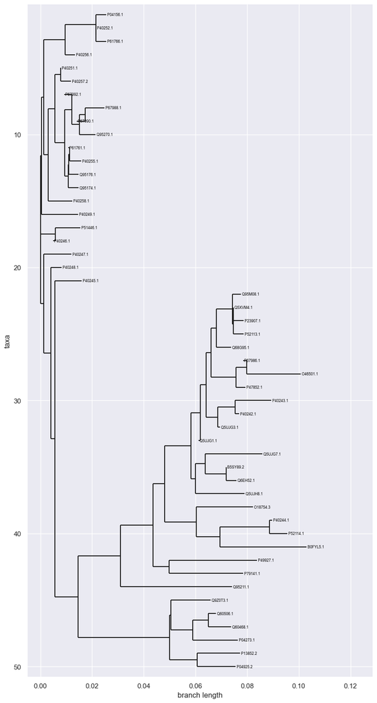

```python
input_file = "D:\\Senior 1 - semester 2\\CSE486 Bioinformatics\\Project_dataset\\Prion_Protein_match_fasta.dnd"
tree = Phylo.read(input_file, "newick")
matplotlib.rc('font', size=6)
fig = plt.figure(figsize=(10, 20), dpi=100)
axes = fig.add_subplot(1, 1, 1)
tree.rooted = True
Phylo.draw(tree, axes=axes)
```

# Printing The Three Sequences That We Are Going To Work On

```python
for seq_record in SeqIO.parse("D:\\Senior 1 - semester 2\\CSE486 Bioinformatics\\Project_dataset\\Prion protein [Homo sapiens].fasta", "fasta"):
    seq_one = seq_record.seq.upper()

seq_two = lines[0].seq.upper()

seq_three = lines[-1].seq.upper()

print("seq_one: {}".format(seq_one))
print()
print("seq_two: {}".format(seq_two))
print()
print("seq_three: {}".format(seq_three))
```

```
seq_one: MANLGCWMLVLFVATWSDLGLCKKRPKPGGWNTGGSRYPGQGSPGGNRYPPQGGGGWGQP…

seq_two: MANLGCWMLVLFVATWSDLGLCKKRPKPGGWNTGGSRYPGQGSPGGNRYPPQGGGGWGQP…

seq_three: MVKSHIGSWILVLFVAMWSDVGLCKKRPKPGGGWNTGGSRYPGQGSPGGNRYPSQGGGGW…
```

# Substitution scores

Substitution scores define the value to be added to the total score when two letters (nucleotides or amino acids) are aligned to each other. The substitution scores to be used by the PairwiseAligner can be specified in Three ways:

1- By specifying a match score for identical letters, and a mismatch scores for mismatched letters

2- By Creating Your Own Substitution Matrices

3- By using the substitution_matrix attribute of the PairwiseAligner object to specify a substitution matrix. This allows you to apply different scores for different pairs of matched and mismatched letters. This is typically used for amino acid sequence alignments.

```python
substitution_matrices.load()
```

```
['BENNER22',
 'BENNER6',
 'BENNER74',
 'BLOSUM45',
 'BLOSUM50',
 'BLOSUM62',
 'BLOSUM80',
 'BLOSUM90',
 'DAYHOFF',
 'FENG',
 'GENETIC',
 'GONNET1992',
 'HOXD70',
 'JOHNSON',
 'JONES',
 'LEVIN',
 'MCLACHLAN',
 'MDM78',
 'NUC.4.4',
 'PAM250',
 'PAM30',
 'PAM70',
 'RAO',
 'RISLER',
 'SCHNEIDER',
 'STR',
 'TRANS']
```

Note:-

By default, aligner.substitution_matrix is None. The attributes aligner.match_score and aligner.mismatch_score are ignored if aligner.substitution_matrix is not None. Setting aligner.match_score or aligner.mismatch_score to valid values will reset aligner.substitution_matrix to None.

## Specifying A Match Score For Identical Letters, And A Mismatch Scores For Mismatched Letters

#### Global Alignment Between seq_one & seq_two

```python
aligner = Align.PairwiseAligner()
aligner.match_score = 2.0
aligner.mismatch_score = -1.0
aligner.gap_score = -1.0
score = aligner.score(seq_one,seq_two)
print(score)
```

```
500.0
```

```python
# The PairwiseAligner object stores all alignment parameters to be used for the pairwise alignments.
print(aligner)
```

```
Pairwise sequence aligner with parameters
  match_score: 2.000000
  mismatch_score: -1.000000
  target_internal_open_gap_score: -1.000000
  target_internal_extend_gap_score: -1.000000
  target_left_open_gap_score: -1.000000
  target_left_extend_gap_score: -1.000000
  target_right_open_gap_score: -1.000000
  target_right_extend_gap_score: -1.000000
  query_internal_open_gap_score: -1.000000
  query_internal_extend_gap_score: -1.000000
  query_left_open_gap_score: -1.000000
  query_left_extend_gap_score: -1.000000
  query_right_open_gap_score: -1.000000
  query_right_extend_gap_score: -1.000000
  mode: global
```

**Note:-**

Depending on the gap scoring parameters and mode, a PairwiseAligner object automatically chooses the appropriate algorithm to use for pairwise sequence alignment. To verify the selected algorithm, use:

```python
aligner.algorithm
```

```
'Needleman-Wunsch'
```

```python
alignments = aligner.align(seq_one, seq_two)
len(alignments)
```

```
1
```

```python
print(alignments[0])
```

```
MANLGCWMLVLFVATWSDLGLCKKRPKPGGWNTGGSRYPGQGSPGGNRYPPQGGGGWGQP…
||||||||||||||||||||||||||||||||||||||||||||||||||||||||||||||||||||||||||||||||||||||||||||||||||||||||||||||||||||||||||||||||.|||||||||||||||||||||||||||||||||||||||||||||||||||||||||||||||||||||||||||||||||||||||||||||||||.||||||||||||||||||||||||||
MANLGCWMLVLFVATWSDLGLCKKRPKPGGWNTGGSRYPGQGSPGGNRYPPQGGGGWGQP…
```

```python
# Use the aligned property to find the start and end indices of subsequences in the target and query sequence
# that were aligned to each other. Generally, if the alignment between target (t) and query (q) consists of N chunks,
# you get two tuples of length N:
alignments[0].aligned
```

```
(((0, 253),), ((0, 253),))
```

Note:-

that different alignments may have the same subsequences aligned to each other. In particular, this may occur if alignments differ from each other in terms of their gap placement only:

#### Global Alignment Between seq_one & seq_three

```python
aligner = Align.PairwiseAligner()
aligner.match_score = 2.0
aligner.mismatch_score = -1.0
aligner.gap_score = -1.0
score = aligner.score(seq_one,seq_three)
print(score)
```

```
425.0
```

```python
aligner.algorithm
```

```
'Needleman-Wunsch'
```

```python
alignments = aligner.align(seq_one,seq_three)
len(alignments)
```

```
1050
```

```python
print(alignments[0])
```

```
MANL--GCWMLVLFVATWSDLGLCKKRPKPGG-WNTGGSRYPGQGSPGGNRYPPQGGGGWGQPHGGGWGQPHGGGWGQPHGGGWGQPHGGGWGQ--GGG------THSQWNKPSKPKTNMKHMAGAAAAGAVVGGLGGYVLGSAMSRPIIHFGSDYEDRYYRENMHRYPNQVYYRPMDEYSNQNNFVHDCVNITIKQHTVTTTTKGENFTETDVKMMERVVEQMCITQYERESQAYYKRGSSMV-LFSSPPVILLISFLIFLIVG
|...--|.|.||||||.|||.|||||||||||-||||||||||||||||||||.||||||||||||||||||||||||||||||||||||||||--|||------||.||||||||||||||.||||||||||||||||.||||||||.||||.|||||||||||.||||||||||.|.|||||||||||||||.||||||||||||||||||.|||||||||||||||.|||.|||.||.|-|-||||||||||||||||||||
MVKSHIGSWILVLFVAMWSDVGLCKKRPKPGGGWNTGGSRYPGQGSPGGNRYPSQGGGGW…-VILFSSPPVILLISFLIFLIVG
```

```python
# Use the aligned property to find the start and end indices of subsequences in the target and query sequence
# that were aligned to each other. Generally, if the alignment between target (t) and query (q) consists of N chunks,
# you get two tuples of length N:
alignments[0].aligned
```

```
(((0, 4), (4, 30), (30, 91), (91, 94), (94, 231), (232, 233), (233, 253)),
 ((0, 4), (6, 32), (33, 94), (96, 99), (105, 242), (242, 243), (244, 264)))
```